# Modelagem de dados II

Rafael N. Magalhães

26-10-2023

## Carregando as bases

```r
library(tidyverse)
library(modelr)
library(gapminder)
library(nycflights13) # banco de dados
library(lubridate) # processamento de datas
```

## Padrões de voos em Nova York

Esta base de dados vai nos ajudar a enxergar a riqueza das ferramentas de previsão e identificação de tendências. Vamos partir de uma base rica sobre voos nos Estados Unidos, e transformá-la em um banco com apenas 365 linhas e 2 colunas, registrando o número de vôos que saem de Nova York todos os dias.

```r
flights
```

## Transformação dos dados

```r
daily <- flights %>%
  mutate(date = make_date(year, month, day)) %>%
  group_by(date) %>%
  summarise(n = n())
```

## Inspeção visual

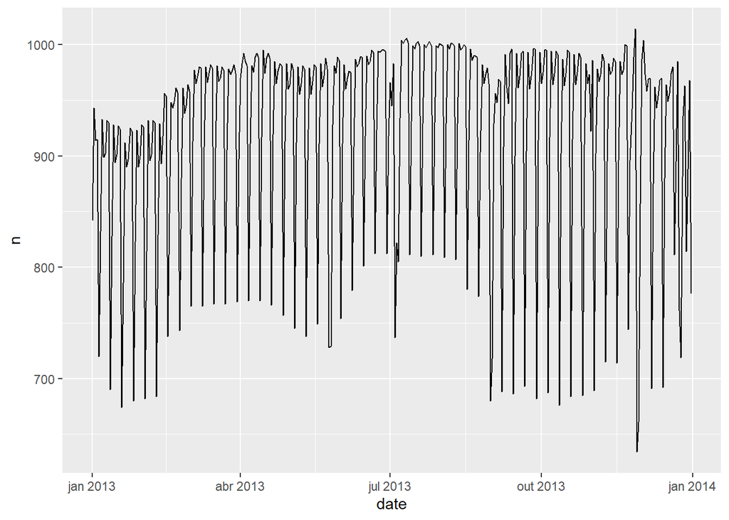

```r
# Há um padrão claro nessa análise exploratória. Quais são os dias com queda tão forte de voos?
ggplot(daily, aes(date, n)) + geom_line()
```

## Voos por dia da semana

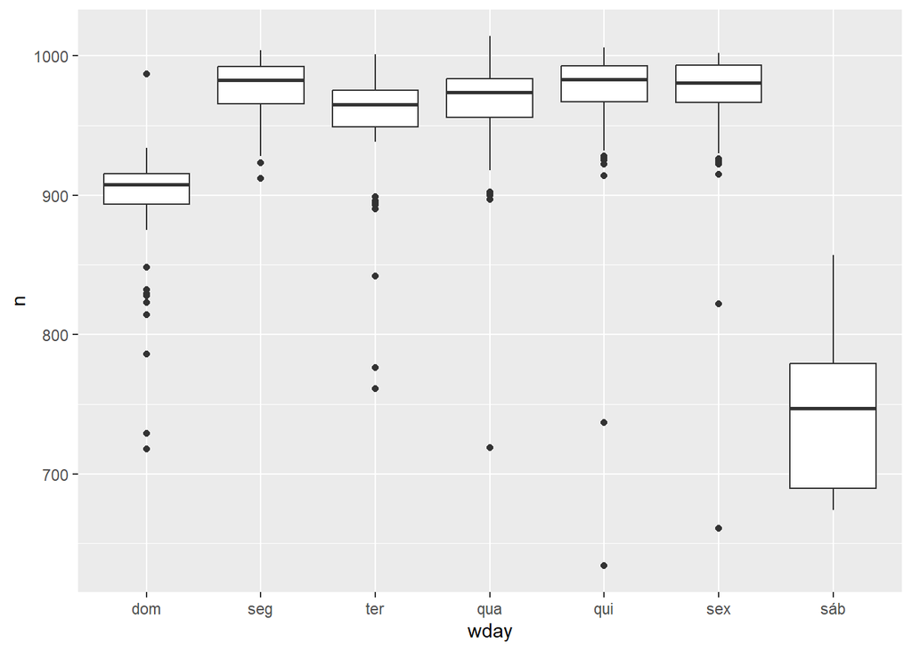

```r
daily <- daily %>% mutate(wday = wday(date, label = TRUE))
ggplot(daily, aes(wday, n)) + geom_boxplot()
```

## Identificação da tendência

Há um padrão claro de menos voos nos fins de semana. Vamos modelar?

```r
mod <- lm(n ~ wday, data = daily)

grid <- daily %>%
  data_grid(wday) %>%
  add_predictions(mod, "n")

ggplot(daily, aes(wday, n)) +
  geom_boxplot() +
  geom_point(data = grid, colour = "red", size = 4)
```

## Identificação da tendência

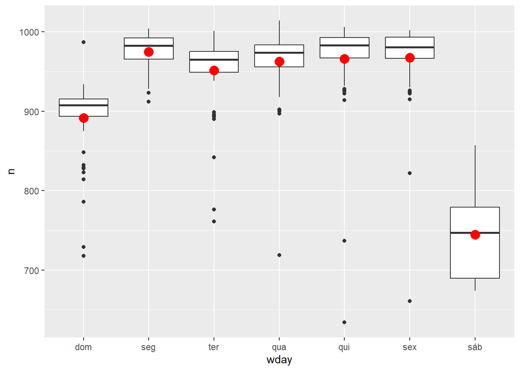

## Visualização dos resíduos

```r
daily <- daily %>%
  add_residuals(mod)

daily %>% ggplot(aes(date, resid)) +
  geom_ref_line(h = 0) +
  geom_line()
```

## Visualização dos resíduos

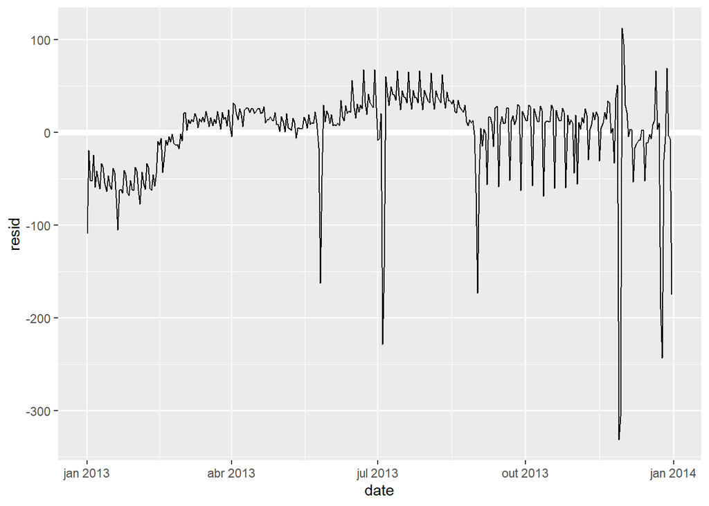

## Análise dos resíduos

O que podemos ver nos resíduos?

1. O modelo não está modelando bem o período de junho, com resíduos regularmente mais altos.

```r
ggplot(daily, aes(date, resid, colour = wday)) +
  geom_ref_line(h = 0) +
  geom_line()
```

## Análise dos resíduos

2. Há alguns dias com bem menos voos do que o esperado

```r
daily %>% filter(resid < -100)
```

## Análise dos resíduos

3. Existe uma tendência de menos voos nos meses de inverno, pareada com maior frequência nos meses de verão

```r
daily %>%
  ggplot(aes(date, resid)) +
  geom_ref_line(h = 0) +
  geom_line(colour = "grey50") +
  geom_smooth(se = FALSE, span = 0.20)
```

## Centrando atenção nos sábados

```r
daily %>%
  filter(wday == "sáb") %>%
  ggplot(aes(date, n)) +
    geom_point() +
    geom_line() +
    scale_x_date(NULL, date_breaks = "1 month", date_labels = "%b")
```

## Centrando atenção nos sábados

Existe uma alta clara no verão, mas o que acontece nos demais períodos? Vamos examinar:

```r
term <- function(date) {
  cut(date,
    breaks = ymd(20130101, 20130605, 20130825, 20140101),
    labels = c("spring", "summer", "fall")
  )
}

daily <- daily %>%
  mutate(term = term(date))

daily %>%
  filter(wday == "sáb") %>%
  ggplot(aes(date, n, colour = term)) +
  geom_point(alpha = 1/3) +
  geom_line() +
  scale_x_date(NULL, date_breaks = "1 month", date_labels = "%b")
```

## Esse padrão se repete nos outros dias?

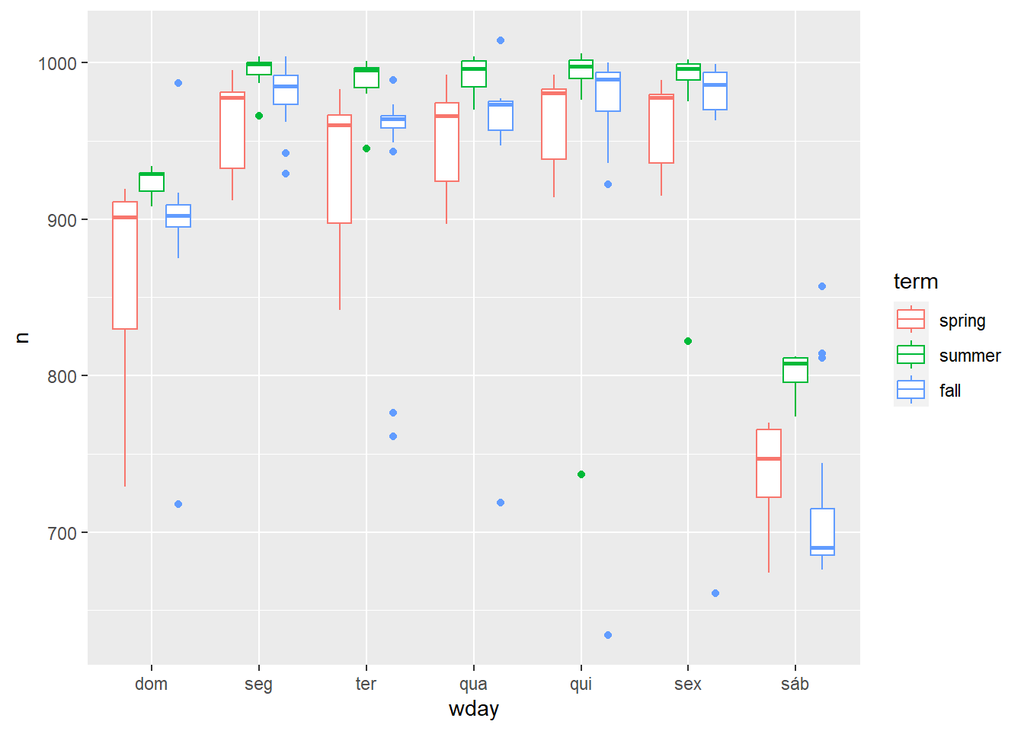

```r
daily %>% ggplot(aes(wday, n, colour = term)) + geom_boxplot()
```

## Análise da interação

```r
mod1 <- lm(n ~ wday, data = daily)
mod2 <- lm(n ~ wday * term, data = daily)

daily %>%
  gather_residuals(without_term = mod1, with_term = mod2) %>%
  ggplot(aes(date, resid, colour = model)) +
    geom_line(alpha = 0.75)
```

## Análise da interação

Podemos observar que os outliers não deixam a interação melhorar o modelo

```r
grid <- daily %>%
  data_grid(wday, term) %>%
  add_predictions(mod2, "n")

ggplot(daily, aes(wday, n)) +
  geom_boxplot() +
  geom_point(data = grid, colour = "red") +
  facet_wrap(~ term)
```

## Modelo robusto

Um modelo robusto melhora bastante nossa previsão

```r
mod3 <- MASS::rlm(n ~ wday * term, data = daily)

daily %>%
  add_residuals(mod3, "resid") %>%
  ggplot(aes(date, resid)) +
  geom_hline(yintercept = 0, size = 2, colour = "white") +
  geom_line()
```

## Ajustando mais de um modelo

## Agora é pra valer!

Agora que temos as técnicas básicas, podemos fazer um exercício mais ambicioso. Vamos rodar vários modelos para entender um banco de dados mais complexo, com fenômenos parecidos com aqueles que costumamos estudar.

Isso vai exigir que a gente armazene resultados em estruturas mais sofisticadas. Assim, vamos conseguir separar tendências mais fortes nos dados para revelar padrões mais sutis, que talvez não pudéssemos capturar à primeira vista.

Vamos responder à seguinte pergunta: como a expectativa de vida evoluiu nos últimos anos em cada país?

```r
gapminder
```

## Evolução por país

Você vê uma tendência?

```r
gapminder %>%
  ggplot(aes(year, lifeExp, group = country)) +
    geom_line(alpha = 1/3)
```

## Análise de um país

```r
nz <- filter(gapminder, country == "New Zealand")
nz %>%
  ggplot(aes(year, lifeExp)) +
  geom_line() +
  ggtitle("Nova Zelândia")
```

## Análise de um país

```r
nz_mod <- lm(lifeExp ~ year, data = nz)
nz %>%
  add_predictions(nz_mod) %>%
  ggplot(aes(year, pred)) +
  geom_line() +
  ggtitle("Tendência Linear")
```

## Análise de um país

```r
nz %>%
  add_residuals(nz_mod) %>%
  ggplot(aes(year, resid)) +
  geom_hline(yintercept = 0, colour = "white", size = 3) +
  geom_line() +
  ggtitle("Resíduo")
```

## Mas e os demais?

Já vimos como decompor o resíduo quando temos apenas um caso. Mas como podemos identificar os países que não seguem a tendência geral que observamos? Temos que rodar um a um?

O princípio da preguiça nos dá a resposta: **não**.

## Dados aninhados

Queremos repetir a mesma operação para diferentes observações na nossa base de dados (ou seja, decompor tendência e resíduo por país).

Vamos usar uma estrutura de dados que tem apenas uma linha para cada país, e uma coluna especial chamada `data`. Esta coluna é uma lista de dataframes (dentro do nosso dataframe!)

```r
by_country <- gapminder %>%
  group_by(country, continent) %>%
  nest()
```

## Dados aninhados

Se olharmos para o valor de apenas uma dessas listas, vemos que ela contem todas as informaçõs, **por ano**, daquele país.

```r
by_country$data[[1]]
```

Portanto, agora temos uma base de dados em que cada linha não é só uma observação; é um conjunto delas!

## Adicionando mais uma lista

Para poder rodar nosso modelo em cada conjunto de observações, vamos criar uma nova função:

```r
country_model <- function(df) {
  lm(lifeExp ~ year, data = df)
}
```

Agora, podemos usar a função `purrr::map` para aplicar nosso modelo a cada conjunto de observações. *And just like that*, temos uma segunda lista de data frames dentro do nosso data frame

```r
by_country <- by_country %>%
  mutate(model = map(data, country_model))
```

## Hora de sair do ninho

Neste ponto, nós temos 142 modelos na nossa base. Para fazer a análise de resíduos em todos eles, seguimos a mesma lógica:

```r
by_country <- by_country %>%
  mutate(resids = map2(data, model, add_residuals))
```

Agora que já temos todos os cálculos que queríamos, podemos desaninhar os modelos para poder colocá-los em gráficos

```r
resids <- unnest(by_country, resids)
```

## Resíduos de todos os países

```r
resids %>%
  ggplot(aes(year, resid)) +
    geom_line(aes(group = country), alpha = 1 / 3) +
    geom_smooth(se = FALSE)
```

## Separando por continente

```r
resids %>%
  ggplot(aes(year, resid, group = country)) +
    geom_line(alpha = 1 / 3) +
    facet_wrap(~continent)
```

## Identificando os piores ajustes

```r
glance <- by_country %>%
  mutate(glance = map(model, broom::glance)) %>%
  unnest(glance) %>%
  arrange(r.squared)

glance
```

## Um olhar para a África

```r
glance %>%
  ggplot(aes(continent, r.squared)) +
    geom_jitter(width = 0.5)
```

## Um olhar para a África

```r
bad_fit <- filter(glance, r.squared < 0.25)

gapminder %>%
  semi_join(bad_fit, by = "country") %>%
  ggplot(aes(year, lifeExp, colour = country)) +
  geom_line()
```

## Atividade

Utilizando o modelo que fizemos para a Nova Zelândia, analise a tendência e os resíduos do Brasil no banco de dados `gapminder`